# P8105 HW 1

Yiying Chen yc4776

2025-09-19

```r
library(moderndive) #call the function for problem 1

library(tidyverse) #call the function for ggplot in problem1 and data frame in problem2
```

## Problem1

```r
data("early_january_weather")
```

#Key variables include time_hour, temperature and humidity.  
#For time_hour, the key value is that  
Min. 1st Qu. Median  
“2013-01-01 01:00:00” “2013-01-04 19:15:00” “2013-01-08 12:30:00”  
Mean 3rd Qu. Max.  
“2013-01-08 12:28:09” “2013-01-12 05:45:00” “2013-01-15 23:00:00” .  
#For temperature, the key value is that  
Min. 1st Qu. Median Mean 3rd Qu. Max.  
24.08 33.98 39.02 39.58 44.96 57.92 .  
#For humidity, the key value is that  
Min. 1st Qu. Median Mean 3rd Qu. Max.  
32.86 51.34 61.67 65.48 78.68 100.00 .  
#All variables are: origin, year, month, day, hour, temp, dewp, humid, wind_dir, wind_speed, wind_gust, precip, pressure, visib, time_hour.  
#This dataset has 358 rows and 15 columns.  
#The mean temperature is 39.5821229 °F.

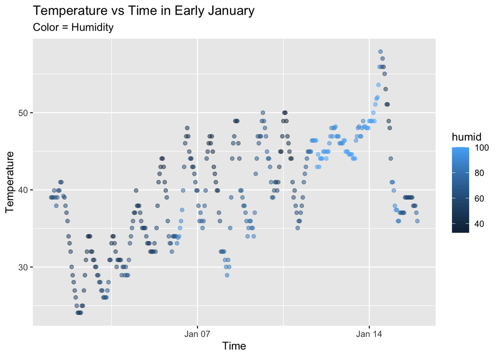

```r
#make ggplot of temperature v.s. time_hour
temp_time_plot <- ggplot(early_january_weather, aes(x = time_hour, y = temp)) +
  geom_point(aes(color = humid), alpha = .5) +
  labs(
    title = "Temperature vs Time in Early January",
    subtitle = "Color = Humidity",
    x = "Time",
    y = "Temperature")

temp_time_plot
```

```r
ggsave("p8105_HW1_plot.png", temp_time_plot, width = 8, height = 5)
```

#Even though the plot is fluctuating, the general pattern is showing an upward trend, with a peak around Jan 14–15.

## Problem2

```r
set.seed(100) #for reproducibility of random samples

#make a data frame for four different kinds of variables
hw1_p2_df <- tibble (
  vec_random = rnorm(10),
  vec_logical = rnorm(10) > 0,
  vec_char = c("red","blue","yellow","purple","green","black","white","grey","pink","orange"),
  vec_factor = factor(c("low","low","low","medium","medium","medium","high","high","high","high"))
)

hw1_p2_df
```

```
## # A tibble: 10 × 4
##    vec_random vec_logical vec_char vec_factor
##         <dbl> <lgl>       <chr>    <fct>
##  1    -0.502  TRUE        red      low
##  2     0.132  TRUE        blue     low
##  3    -0.0789 FALSE       yellow   low
##  4     0.887  TRUE        purple   medium
##  5     0.117  TRUE        green    medium
##  6     0.319  FALSE       black    medium
##  7    -0.582  FALSE       white    high
##  8     0.715  TRUE        grey     high
##  9    -0.825  FALSE       pink     high
## 10    -0.360  TRUE        orange   high
```

```r
#calculate for the mean of each variable
mean_random <- mean(hw1_p2_df %>% pull(vec_random))
mean_random
```

```
## [1] -0.01795716
```

```r
mean_logical <- mean(hw1_p2_df %>% pull(vec_logical))
mean_logical
```

```
## [1] 0.6
```

```r
mean_char <- mean(hw1_p2_df %>% pull(vec_char))
mean_char
```

```
## [1] NA
```

```r
mean_factor <- mean(hw1_p2_df %>% pull(vec_factor))
mean_factor
```

```
## [1] NA
```

#We can see that only the random sample and random vector. The result shows NA for characters and factor.

```r
#test if each variable can be turned into numerical value
as.numeric(hw1_p2_df %>% pull(vec_random))
as.numeric(hw1_p2_df %>% pull(vec_logical))
as.numeric(hw1_p2_df %>% pull(vec_char))
as.numeric(hw1_p2_df %>% pull(vec_factor))
```

[output not shown]